# Tugas MPDW - Pemodelan Regresi dengan Peubah Lag (Koyck, DLM, ARDL)

Adi Pratama

2026-09-03

## Tugas Individu

**Instruksi:**

1. Gunakan dataset kualitas udara pada Google Drive: [[Link GDrive]](https://drive.google.com/drive/folders/18ZcJpGKzmwlw9zxGZjTtVnJV0Ufau23g?usp=drive_link)
2. Tetapkan AQI sebagai variabel dependen (Y), lalu pilih satu variabel polutan (CO, NO₂, O₃, PM10, PM2.5, atau SO₂) sebagai variabel independen (X).
3. Terapkan ketiga metode regresi dengan peubah lag yang sudah dipelajari (Koyck, DLM, dan ARDL). Tentukan lag optimum untuk masing-masing metode!
4. Lakukan evaluasi asumsi model dan bandingkan kinerja peramalan menggunakan metrik akurasi (MAPE) serta visualisasi grafik.
5. *Upload* *dataset* dan tugas per individu ke GitHub pada folder `Pertemuan-3` dengan format HTML bernama: `Tugas-Pertemuan-3.html` dan `.Rmd`.
6. **Deadline Pengumpulan:** Kamis, 10 September 2026, 23.59 WIB.

## 1. Persiapan Data

### *Packages*

```r
library(dLagM)
library(dynlm)
library(MLmetrics)
library(lmtest)
library(car)
library(tseries)
```

### Impor & Pembagian Data

Kita akan menggunakan data New Delhi untuk melatih pemodelan. Data dibagi menjadi data Training (untuk membentuk model) dan data Testing (untuk menguji akurasi ramalan).

```r
# Impor Data (sesuaikan path file jika diperlukan)
data_raw <- read.csv("NewDelhi_Air_quality.csv")
data_raw
```

```
##     X  AQI       CO      datetime        no2       o3      pm10     pm25
## 1   0 30.2 198.6027 2022-10-21:18 0.04685717 55.78995 10.486722 5.637410
## 2   1 28.2 197.6013 2022-10-21:19 0.04645554 54.93164 10.719325 4.618169
## 3   2 26.6 198.6027 2022-10-21:20 0.04685717 54.64554 11.155578 3.520902
## 4   3 25.0 201.9405 2022-10-21:21 0.04819594 55.07469 11.116206 2.225919
## 5   4 26.0 205.2784 2022-10-21:22 0.04886533 55.78995 10.405250 1.979471
## 6   5 26.0 208.6163 2022-10-21:23 0.05020411 56.50520  9.402518 1.792677
## 7   6 26.0 208.6163 2022-10-22:00 0.05020411 55.78995  8.482822 1.752237
## 8   7 24.0 205.2784 2022-10-22:01 0.05020411 52.92892  7.586667 1.858459
## 9   8 23.0 200.2716 2022-10-22:02 0.04685717 50.06790  7.636587 2.208076
## 10  9 24.0 196.9338 2022-10-22:03 0.04417961 51.49841  8.487648 2.476681
## 11 10 25.0 198.6027 2022-10-22:04 0.04284084 53.64418  9.357371 2.585729
## 12 11 26.0 200.2716 2022-10-22:05 0.04049798 55.78995 10.338728 2.390081
## 13 12 27.0 203.6095 2022-10-22:06 0.04016329 59.36623 10.523314 2.086022
## 14 13 29.0 205.2784 2022-10-22:07 0.03882451 62.22725 10.635970 1.937047
```

[output cut: 131 more lines]

```r
# Memilih kolom yang relevan: AQI sebagai Y dan PM2.5 sebagai X
# Pastikan nama kolom sesuai dengan header di file CSV Anda (misal: AQI dan PM2.5)
data <- data.frame(
  Yt = data_raw$AQI,
  Xt = data_raw$pm25
)

# Cek struktur data
head(data)
```

```
##     Yt       Xt
## 1 30.2 5.637410
## 2 28.2 4.618169
## 3 26.6 3.520902
## 4 25.0 2.225919
## 5 26.0 1.979471
## 6 26.0 1.792677
```

```r
str(data)
```

```
## 'data.frame':    72 obs. of  2 variables:
##  $ Yt: num  30.2 28.2 26.6 25 26 26 26 24 23 24 ...
##  $ Xt: num  5.64 4.62 3.52 2.23 1.98 ...
```

```r
# Membagi data menjadi Training (56 observasi) dan Testing (16 observasi) dari total 72 baris
train <- data[1:56, ]
test <- data[57:72, ]
```

## 2. Model Koyck

### Pemodelan

```r
# Membangun Model Koyck
model.koyck <- koyckDlm(x = train$Xt, y = train$Yt)
summary(model.koyck)
```

```
##
## Call:
## "Y ~ (Intercept) + Y.1 + X.t"
##
## Residuals:
##      Min       1Q   Median       3Q      Max
## -2.22320 -0.52004 -0.06403  0.62325  2.17303
##
## Coefficients:
##             Estimate Std. Error t value Pr(>|t|)
## (Intercept)  4.71635    1.77511   2.657   0.0104 *
## Y.1          0.86814    0.05733  15.142   <2e-16 ***
## X.t         -0.57288    0.27583  -2.077   0.0428 *
## ---
## Signif. codes:  0 '***' 0.001 '**' 0.01 '*' 0.05 '.' 0.1 ' ' 1
##
## Residual standard error: 0.8966 on 52 degrees of freedom
## Multiple R-Squared: 0.8311,  Adjusted R-squared: 0.8246
## Wald test: 128.2 on 2 and 52 DF,  p-value: < 2.2e-16
##
## Diagnostic tests:
## NULL
##
##                             alpha       beta       phi
## Geometric coefficients:  35.76659 -0.5728788 0.8681353
```

**Interpretasi:**

- **Untuk peubah** $Y_{t-1}$ ($p\text{-value} < 2 \times 10^{-16}$): Karena nilainya jauh di bawah $0.05$, maka $Y_{t-1}$ berpengaruh sangat signifikan terhadap $Y_t$. Ini berarti kondisi AQI di masa lalu ($\lambda$) memiliki peran yang sangat kuat dalam menentukan AQI hari ini.
- **Untuk peubah** $X_t$ / PM2.5 ($p\text{-value} = 0.0428$): Karena nilainya $0.0428$ (di bawah $0.05$), maka $X_t$ juga berpengaruh signifikan terhadap $Y_t$. Artinya, tingkat polutan PM2.5 saat ini berdampak langsung secara nyata terhadap AQI.

Jadi, **karena kedua peubah tersebut memiliki *p-value*** $< 0.05$, maka keduanya terbukti berpengaruh signifikan

### Peramalan

```r
# Meramalkan 16 periode ke depan
fore.koyck <- forecast(model = model.koyck, x = test$Xt, h = 16)
fore.koyck
```

```
## $forecasts
##  [1] 26.01034 25.86405 25.59408 25.22576 24.85931 24.51103 24.22483 24.04170
##  [9] 23.95688 23.92621 23.92309 23.92633 23.93336 23.92231 23.89154 23.88438
##
## $call
## forecast.koyckDlm(model = model.koyck, x = test$Xt, h = 16)
##
## attr(,"class")
## [1] "forecast.koyckDlm" "dLagM"
```

```r
# Cek Akurasi (MAPE) pada data testing
mape.koyck <- MAPE(fore.koyck$forecasts, test$Yt)
cat("MAPE Model Koyck:", mape.koyck, "\n")
```

```
## MAPE Model Koyck: 0.1494582
```

## 3. Regression with Distributed Lag (DLM)

### Penentuan *Lag* Optimum

Untuk menghindari coba-coba, kita bisa mencari nilai $q$ terbaik berdasarkan nilai *Akaike Information Criterion (AIC)* terkecil menggunakan fungsi `finiteDLMauto()`.

```r
# Pencarian q optimum dari q.min = 1 hingga q.max = 8
finiteDLMauto(formula = Yt ~ Xt,
              data = data.frame(train),
              q.min = 1, q.max = 8,
              model.type = "dlm",
              error.type = "AIC",
              trace = TRUE)
```

```
##   q - k    MASE      AIC      BIC    GMRAE    MBRAE R.Adj.Sq    Ljung-Box
## 8     8 2.07013 193.8008 214.3840 64259.27  0.70039  0.44686 3.272457e-10
## 7     7 2.02848 194.8848 213.8030 52370.81  0.63363  0.48326 9.484402e-10
## 6     6 1.89401 195.9280 213.1362 37066.75  0.56886  0.49629 7.440113e-10
## 5     5 1.91689 198.9083 214.3629 40186.35 -0.24196  0.48886 1.351843e-09
## 4     4 2.02920 204.5826 218.2413 58610.48  0.74868  0.45346 5.091999e-09
## 3     3 2.28631 214.2502 226.0720 61135.77  0.80989  0.37954 1.904447e-09
## 2     2 2.33240 226.1932 236.1381 47538.63  0.92969  0.25489 8.364184e-07
## 1     1 2.41927 238.3432 246.3725 38320.49  0.60002  0.10959 2.706114e-09
```

**Interpretasi:** Pilih baris dengan nilai AIC yang paling kecil. Lag optimum berada pada $q=8$, kita bangun ulang modelnya:

```r
# Membangun ulang DLM dengan Lag Optimum (q=6)
model.dlm.opt <- dlm(x = train$Xt, y = train$Yt, q = 8)
summary(model.dlm.opt)
```

```
##
## Call:
## lm(formula = model.formula, data = design)
##
## Residuals:
##     Min      1Q  Median      3Q     Max
## -2.1402 -0.9565 -0.3015  0.8532  3.4203
##
## Coefficients:
##             Estimate Std. Error t value Pr(>|t|)
## (Intercept)  37.2377     2.2650  16.440   <2e-16 ***
## x.t         -11.0075     5.5527  -1.982   0.0547 .
## x.1           8.3682    12.4375   0.673   0.5051
## x.2          -4.9088    14.8111  -0.331   0.7421
## x.3           3.6355    14.6835   0.248   0.8058
## x.4          -2.3787    12.4811  -0.191   0.8499
## x.5           2.9279     7.1071   0.412   0.6827
## x.6          -0.3448     4.0696  -0.085   0.9329
## x.7          -1.9335     3.7549  -0.515   0.6096
## x.8           0.7997     1.7268   0.463   0.6459
## ---
## Signif. codes:  0 '***' 0.001 '**' 0.01 '*' 0.05 '.' 0.1 ' ' 1
##
## Residual standard error: 1.628 on 38 degrees of freedom
## Multiple R-squared:  0.5528, Adjusted R-squared:  0.4469
## F-statistic: 5.219 on 9 and 38 DF,  p-value: 0.000126
##
## AIC and BIC values for the model:
##        AIC     BIC
## 1 193.8008 214.384
```

```r
# Peramalan model DLM Optimum
fore.dlm.opt <- forecast(model = model.dlm.opt, x = test$Xt, h = 16)
mape.dlm.opt <- MAPE(fore.dlm.opt$forecasts, test$Yt)
cat("MAPE Model DLM Optimum (q=8):", mape.dlm.opt * 100, "%\n")
```

```
## MAPE Model DLM Optimum (q=8): 10.23765 %
```

## 4. Autoregressive Distributed Lag (ARDL)

### *Lag* Optimum ARDL

Kita bisa mencari kombinasi $p$ dan $q$ terbaik dengan fungsi `ardlBoundOrders()`.

```r
# Mencari kombinasi lag optimum berdasarkan AIC
model.ardl.opt <- ardlBoundOrders(data = data.frame(data), ic = "AIC", formula = Yt ~ Xt)

# Menentukan p dan q optimum secara otomatis
min_p <- c()
for(i in 1:4){
  min_p[i] <- min(model.ardl.opt$Stat.table[[i]], na.rm = TRUE)
}
q_opt_ardl <- which(min_p == min(min_p, na.rm = TRUE))
p_opt_ardl <- which(model.ardl.opt$Stat.table[[q_opt_ardl]] == min(model.ardl.opt$Stat.table[[q_opt_ardl]], na.rm = TRUE))

cat("Lag Optimum ARDL -> p (untuk X):", p_opt_ardl, "| q (untuk Y):", q_opt_ardl, "\n")
```

```
## Lag Optimum ARDL -> p (untuk X): 15 | q (untuk Y): 3
```

```r
# Membangun Model ARDL Optimum pada data training
model.ardl <- ardlDlm(formula = Yt ~ Xt, data = train, p = p_opt_ardl, q = q_opt_ardl)
summary(model.ardl)
```

```
##
## Time series regression with "ts" data:
## Start = 16, End = 56
##
## Call:
## dynlm(formula = as.formula(model.text), data = data)
##
## Residuals:
##      Min       1Q   Median       3Q      Max
## -1.05821 -0.23512 -0.00703  0.22756  1.00814
##
## Coefficients:
##             Estimate Std. Error t value Pr(>|t|)
## (Intercept)  11.3498    10.6341   1.067  0.29795
## Xt.t        -13.5785     5.2602  -2.581  0.01741 *
## Xt.1         16.4543     9.1520   1.798  0.08659 .
## Xt.2         -2.6125    10.8135  -0.242  0.81144
## Xt.3         -2.2299    12.0293  -0.185  0.85472
## Xt.4         -0.5787    14.1572  -0.041  0.96778
## Xt.5          4.0882    13.1278   0.311  0.75855
## Xt.6          1.5114    11.2717   0.134  0.89461
## Xt.7         -7.7377    11.3271  -0.683  0.50200
## Xt.8          1.3065    10.8446   0.120  0.90525
## Xt.9          4.1484     9.7741   0.424  0.67557
## Xt.10        -3.6333     8.8554  -0.410  0.68575
## Xt.11        -0.7482     6.9949  -0.107  0.91583
## Xt.12         3.4624     4.4242   0.783  0.44260
## Xt.13        -1.9629     3.3106  -0.593  0.55956
## Xt.14        -1.2351     3.3069  -0.373  0.71253
## Xt.15         0.9688     1.7738   0.546  0.59071
## Yt.1          0.7691     0.2515   3.058  0.00597 **
## Yt.2          0.3197     0.3069   1.042  0.30940
## Yt.3         -0.3283     0.2155  -1.523  0.14263
## ---
## Signif. codes:  0 '***' 0.001 '**' 0.01 '*' 0.05 '.' 0.1 ' ' 1
##
## Residual standard error: 0.6986 on 21 degrees of freedom
## Multiple R-squared:  0.943,  Adjusted R-squared:  0.8915
## F-statistic:  18.3 on 19 and 21 DF,  p-value: 4.668e-09
```

```r
# Peramalan ARDL
fore.ardl <- forecast(model = model.ardl, x = test$Xt, h = 16)
mape.ardl <- MAPE(fore.ardl$forecasts, test$Yt)
cat("MAPE Model ARDL:", mape.ardl * 100, "%\n")
```

```
## MAPE Model ARDL: 16.00814 %
```

## Perbandingan Performa Model

Mari kita bandingkan akurasi peramalan berdasarkan MAPE dan memvisualisasikannya.

### Akurasi

```r
# Rekapitulasi MAPE
akurasi <- data.frame(
  Model = c("Koyck", "DLM Optimum", "ARDL Optimum"),
  MAPE_Persen = c(mape.koyck * 100, mape.dlm.opt * 100, mape.ardl * 100)
)
print(akurasi)
```

```
##          Model MAPE_Persen
## 1        Koyck    14.94582
## 2  DLM Optimum    10.23765
## 3 ARDL Optimum    16.00814
```

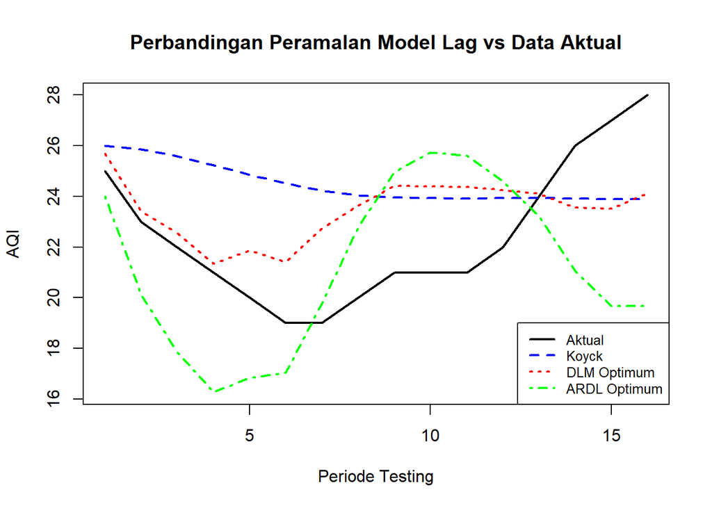

```r
# Plot perbandingan nilai aktual vs hasil ramalan ketiga model pada data testing
plot(test$Yt, type = "l", col = "black", lwd = 2, ylim = range(c(test$Yt, fore.koyck$forecasts, fore.dlm.opt$forecasts, fore.ardl$forecasts)),
     main = "Perbandingan Peramalan Model Lag vs Data Aktual", ylab = "AQI", xlab = "Periode Testing")
lines(fore.koyck$forecasts, col = "blue", lwd = 2, lty = 2)
lines(fore.dlm.opt$forecasts, col = "red", lwd = 2, lty = 3)
lines(fore.ardl$forecasts, col = "green", lwd = 2, lty = 4)

legend("bottomright", legend = c("Aktual", "Koyck", "DLM Optimum", "ARDL Optimum"),
       col = c("black", "blue", "red", "green"), lty = c(1, 2, 3, 4), lwd = 2, cex = 0.8)
```

### Kesimpulan

Model Distributed Lag Model (DLM) Optimum memberikan kinerja peramalan terbaik dibandingkan model lainnya, dengan nilai MAPE terendah yaitu 10,24%. Berdasarkan kriteria umum interpretasi nilai MAPE , performa DLM Optimum berada pada kategori baik dan akurat dalam memprediksi nilai AQI menggunakan data PM2.5.

Diikuti oleh Model Koyck di posisi kedua dengan nilai MAPE sebesar 14,95%, yang juga masih menunjukkan kemampuan peramalan yang cukup baik. Sementara itu, Model ARDL Optimum memiliki tingkat kesalahan tertinggi dengan nilai MAPE sebesar 16,01%, meskipun secara umum masih berada dalam batas toleransi akurasi prediksi yang wajar untuk data deret waktu jangka pendek. Dengan demikian, **DLM Optimum** adalah model yang **paling direkomendasikan** untuk peramalan AQI **pada studi kasus ini**.